# Data Preparation

Generally we will do the following steps in preparing the dataset before we can do any data analysis in a machine learning system:

- Reading the data
- Handling any missing data
- Handling any categorical data
- Scaling the data
- Splitting training and test data

Some packages are needed for data analysis:

```python
import numpy as np
import pandas as pd
import matplotlib.pyplot as plt
%matplotlib notebook
```

.

**Step 1: Reading the Dataset**

It is common to have dataset contained in the Excel Sheet as .csv file format, like below *Data.csv*:

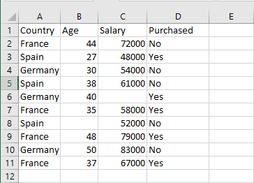

Here how to read the CSV file, retrieve the dataset and store it into a data frame *mydataset* and print it. The type of the *mydataset* is DataFrame of the *pandas* package.

```python
mydataset = pd.read_csv('Data.csv')
print('The head (the first 5 records) of the dataset: \n\n', mydataset.head())
print('\nType of mydataset: ', type(mydataset))
print('Shape/size of mydataset: ', mydataset.shape)
print('Columns name of mydataset: ', mydataset.columns)
```

```
The head (the first 5 records) of the dataset:

    Country   Age   Salary Purchased
0   France  44.0  72000.0        No
1    Spain  27.0  48000.0       Yes
2  Germany  30.0  54000.0        No
3    Spain  38.0  61000.0        No
4  Germany  40.0      NaN       Yes

Type of mydataset:  <class 'pandas.core.frame.DataFrame'>
Shape/size of mydataset:  (10, 4)
Columns name of mydataset:  Index(['Country', 'Age', 'Salary', 'Purchased'], dtype='object')
```

The *mydataset* has 10 records. Each has 3 independent variables (IV), and 1 dependent variable (DV). The IVs are *Country*, *Age* and *Salary*, and the DV is *Purchased*. The *Purchased* depends on the variables *Country*, *Age* and *Salary*. Other names for IV are **predictor, feature**, or **attribute**, while for DV, **output**, or **outcome**. We will use the term **predictor** and **outcome** for short. Now retrieve the predictors and the outcome (from *mydataset*), store into arrays:

```python
X = mydataset.iloc[:, :-1].values  # Extract all rows (:), and all columns but minus 1 (:-1), i.e. last column removed
y = mydataset.iloc[:, 3].values    # Extract all rows and only one column less than 3, i.e. column 2
                                   # Note that row and column number start with 0
print('The type of X: ', type(X))
print('The size of X: ', X.shape)
print("The X: \n", X)
print('\n\nThe type of y: ', type(y))
print('The size of y: ', y.shape)
print('The y:\n', y)
```

```
The type of X:  <class 'numpy.ndarray'>
The size of X:  (10, 3)
The X:
 [['France' 44.0 72000.0]
 ['Spain' 27.0 48000.0]
 ['Germany' 30.0 54000.0]
 ['Spain' 38.0 61000.0]
 ['Germany' 40.0 nan]
 ['France' 35.0 58000.0]
 ['Spain' nan 52000.0]
 ['France' 48.0 79000.0]
 ['Germany' 50.0 83000.0]
 ['France' 37.0 67000.0]]


The type of y:  <class 'numpy.ndarray'>
The size of y:  (10,)
The y:
 ['No' 'Yes' 'No' 'No' 'Yes' 'Yes' 'No' 'Yes' 'No' 'Yes']
```

The $X$ and the $y$ are arrays defined by *numpy*. There is another way to obtain the same arrays but still keeping the DataFrame type. The DataFrame type gives a more convenient way in extracting information and visualizing it.

```python
X_col = mydataset[['Country', 'Age', 'Salary']]      # The X_col and y_col are remain in panda's DataFrame type
y_col = mydataset[['Purchased']]
print('The type of X_col: ', type(X_col))
print('The size of X_col: ', X_col.shape)
print('\nThe X_col: \n', X_col)
print('\nThe y_col: \n', y_col)
```

```
The type of X_col:  <class 'pandas.core.frame.DataFrame'>
The size of X_col:  (10, 3)

The X_col:
    Country   Age   Salary
0   France  44.0  72000.0
1    Spain  27.0  48000.0
2  Germany  30.0  54000.0
3    Spain  38.0  61000.0
4  Germany  40.0      NaN
5   France  35.0  58000.0
6    Spain   NaN  52000.0
7   France  48.0  79000.0
8  Germany  50.0  83000.0
9   France  37.0  67000.0

The y_col:
   Purchased
0        No
1       Yes
2        No
3        No
4       Yes
5       Yes
6        No
7       Yes
8        No
9       Yes
```

If you want, you can convert the array's type from panda's DataFrame to numpy's array:

```python
X_arr = np.array(X_col) # The X_col (DataFrame) can be converted to a numpy array
print('The X_arr: \n', X_arr)
print('\nX_arr size: ', X_arr.shape)
```

```
The X_arr:
 [['France' 44.0 72000.0]
 ['Spain' 27.0 48000.0]
 ['Germany' 30.0 54000.0]
 ['Spain' 38.0 61000.0]
 ['Germany' 40.0 nan]
 ['France' 35.0 58000.0]
 ['Spain' nan 52000.0]
 ['France' 48.0 79000.0]
 ['Germany' 50.0 83000.0]
 ['France' 37.0 67000.0]]

X_arr size:  (10, 3)
```

.

**Step 2: Handling The Missing Data**

The $X$ has missing data, which are replaced with *nan*. This missing data comes from the empty cells in the CSV file. The technique to deal with this missing data is to fill it with the average of its column or row. We use *Imputer* class from *sklearn* package, by creating an *imputer* object. The method *fit* from this object is used to replace the *nan* with values.

```python
from sklearn.impute import SimpleImputer
myimputer = SimpleImputer(missing_values = np.nan, strategy = 'mean')
myimputer = myimputer.fit(X[:, 1:3]) # all rows, but only column 1 and subsequent columns less than 3
X[:, 1:3] = myimputer.transform(X[:, 1:3])
print(X)
```

```
[['France' 44.0 72000.0]
 ['Spain' 27.0 48000.0]
 ['Germany' 30.0 54000.0]
 ['Spain' 38.0 61000.0]
 ['Germany' 40.0 63777.77777777778]
 ['France' 35.0 58000.0]
 ['Spain' 38.77777777777778 52000.0]
 ['France' 48.0 79000.0]
 ['Germany' 50.0 83000.0]
 ['France' 37.0 67000.0]]
```

You may want to save the dataset to a CSV file. Here we retrieve the numpy's array $Z$ from the dataset, fill the empty data and write back into files:

```python
Z = mydataset.iloc[:, :].values # get all dataset into an numpy array size (10,4)
myimputer = SimpleImputer(missing_values = np.nan, strategy='mean')
myimputer = myimputer.fit(Z[:, 1:3]) # fit with Z col 1 to 2, i.e. Age and Salary
Z[:, 1:3] = myimputer.transform(Z[:, 1:3])

# now write to the CSV files with various styles
pd.DataFrame(Z).to_csv("DataZ-0.csv")
pd.DataFrame(Z).to_csv("DataZ-1.csv", header=None, index=None)
pd.DataFrame(Z).to_csv("DataZ-2.csv", header=['TheCountry','TheAge','TheSalary','Purchased'], index=None)
```

Here is the *DataZ-0.csv*:

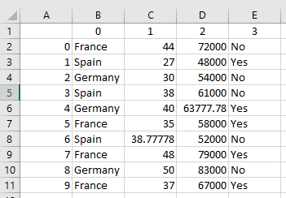

Here is the *DataZ-1.csv*:

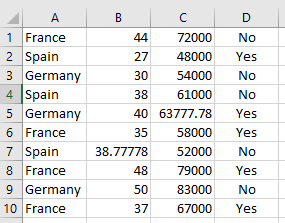

Here is the *DataZ-2.csv*:

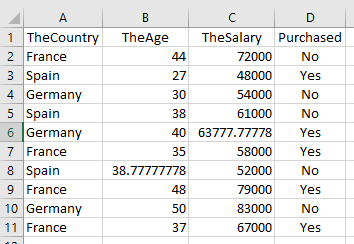

.

**Step 3: Handling Categorical Data**

The predictor array $X$ has categorical data in the form of string in col-0. This string variable cannot be included into a numerical data analysis. So we need to convert it into numerical data. Array $X$ has col-0 values *'France', 'Germany'* and *'Spain'*. We can make a label on this category, and encode them into numeric. Encoding is ordered based on alphabet. Please notice the col-0 of $X$, after conversion:

```python
from sklearn.preprocessing import OneHotEncoder
print('The X: \n', X)
country = np.unique(X[:,0])
ohe = OneHotEncoder(categories=[country])
Xcol0 = ohe.fit_transform(X[:, 0:1]).toarray()
Xcoded = np.append(Xcol0, X[:, 1:3], axis=1)
print('\nThe encoded Xcoded: \n', Xcoded)
```

```
The X:
 [['France' 44.0 72000.0]
 ['Spain' 27.0 48000.0]
 ['Germany' 30.0 54000.0]
 ['Spain' 38.0 61000.0]
 ['Germany' 40.0 63777.77777777778]
 ['France' 35.0 58000.0]
 ['Spain' 38.77777777777778 52000.0]
 ['France' 48.0 79000.0]
 ['Germany' 50.0 83000.0]
 ['France' 37.0 67000.0]]

The encoded Xcoded:
 [[1.0 0.0 0.0 44.0 72000.0]
 [0.0 0.0 1.0 27.0 48000.0]
 [0.0 1.0 0.0 30.0 54000.0]
 [0.0 0.0 1.0 38.0 61000.0]
 [0.0 1.0 0.0 40.0 63777.77777777778]
 [1.0 0.0 0.0 35.0 58000.0]
 [0.0 0.0 1.0 38.77777777777778 52000.0]
 [1.0 0.0 0.0 48.0 79000.0]
 [0.0 1.0 0.0 50.0 83000.0]
 [1.0 0.0 0.0 37.0 67000.0]]
```

We will also encode the outcome $y$ too:

```python
from sklearn.preprocessing import OneHotEncoder
print('The y: \n', y)
ycoded = np.reshape(y,(len(y),1))
purch = np.unique(ycoded[:,0])
ohe = OneHotEncoder(categories=[purch])
ycoded = ohe.fit_transform(ycoded[:, 0:1]).toarray()
print('\nThe encoded ycoded: \n', ycoded)
```

```
The y:
 ['No' 'Yes' 'No' 'No' 'Yes' 'Yes' 'No' 'Yes' 'No' 'Yes']

The encoded ycoded:
 [[1. 0.]
 [0. 1.]
 [1. 0.]
 [1. 0.]
 [0. 1.]
 [0. 1.]
 [1. 0.]
 [0. 1.]
 [1. 0.]
 [0. 1.]]
```

.

**Dummy Variable Trap**

```python
print(Xcoded[:,:])
```

```
[[1.0 0.0 0.0 44.0 72000.0]
 [0.0 0.0 1.0 27.0 48000.0]
 [0.0 1.0 0.0 30.0 54000.0]
 [0.0 0.0 1.0 38.0 61000.0]
 [0.0 1.0 0.0 40.0 63777.77777777778]
 [1.0 0.0 0.0 35.0 58000.0]
 [0.0 0.0 1.0 38.77777777777778 52000.0]
 [1.0 0.0 0.0 48.0 79000.0]
 [0.0 1.0 0.0 50.0 83000.0]
 [1.0 0.0 0.0 37.0 67000.0]]
```

From binary number perspective, we need to encode 3 categories, so 2 bits are sufficient, which are represented by col-1 and col-2. It then allows us to remove col-0:

```python
Xcodedclean = Xcoded[:, 1:]
print("The Xcodedclean: \n", Xcodedclean)
print("Shape of Xcodedclean: ", Xcodedclean.shape)
```

```
The Xcodedclean:
 [[0.0 0.0 44.0 72000.0]
 [0.0 1.0 27.0 48000.0]
 [1.0 0.0 30.0 54000.0]
 [0.0 1.0 38.0 61000.0]
 [1.0 0.0 40.0 63777.77777777778]
 [0.0 0.0 35.0 58000.0]
 [0.0 1.0 38.77777777777778 52000.0]
 [0.0 0.0 48.0 79000.0]
 [1.0 0.0 50.0 83000.0]
 [0.0 0.0 37.0 67000.0]]
Shape of Xcodedclean:  (10, 4)
```

Let's transfer the $Xcodedclean$ back to the original predictor array $X$, and also save it into a file. You can do the same way with the $y$.

```python
X = Xcodedclean
np.savetxt("Data-X.csv", X, delimiter=",") # Let's save the X into a CSV
```

.

**Step 4: Scaling The Variables**

If we look at the predictor $X$ ( I have saved it into *Data-X.csv*), there is unscaled range of data between *Salary* and *Age* predictor. It can cause problem as the machine may ignore the *Age* due to very low value as compared with the *Salary*. So we need to scale the predictor.

Note that the machine is interested in predicting the impact of each independent variable to the outcome, not on the absolute value of the predictor.

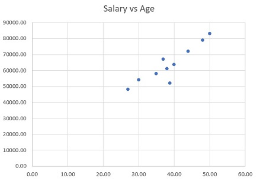

So let us do the scaling:

```python
from sklearn.preprocessing import StandardScaler
sc_X = StandardScaler() # create object, for calling its method
Xscaled = sc_X.fit_transform(X)    # fit first and then transform
                                   # directly transform, as already fit previously
                                   # fit with the same scaling
print(Xscaled[0:5, :])
np.savetxt("Data-Xscaled.csv", Xscaled, delimiter=",") # Let's save the X into a CSV
```

```
[[-6.54653671e-01 -6.54653671e-01  7.58874362e-01  7.49473254e-01]
 [-6.54653671e-01  1.52752523e+00 -1.71150388e+00 -1.43817841e+00]
 [ 1.52752523e+00 -6.54653671e-01 -1.27555478e+00 -8.91265492e-01]
 [-6.54653671e-01  1.52752523e+00 -1.13023841e-01 -2.53200424e-01]
 [ 1.52752523e+00 -6.54653671e-01  1.77608893e-01  6.63219199e-16]]
```

Here now we have the same scale for both *Salary* and *Age* as below plot. As you notice, the pattern is still the same, only that the absolute value changes:

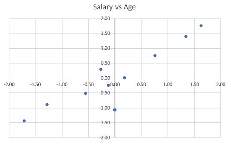

.

**Step 5: Training Data and Test Data**

Now we will split the input data into Training Data and Test Data. Training Data is used to train the machine to learn and generate a model. The Test Data is used to test the generated model. How much is the test data set aside from the entire dataset? Typically is 20% (0.2). Here is the way to split the input dataset. Note that the split is for both predictor array and outcome array.

The *X_train* and *y_train* are training data, and the *X_test* and *y_test* are test data.

```python
from sklearn.model_selection import train_test_split
X_train, X_test, y_train, y_test = train_test_split(X, y, test_size=0.2, random_state=0)
print("The X_train: \n",X_train)
print("The X_test: \n",X_test)
print("The y_train: \n",y_train)
print("The y_test: \n",y_test)
```

```
The X_train:
 [[1.0 0.0 40.0 63777.77777777778]
 [0.0 0.0 37.0 67000.0]
 [0.0 1.0 27.0 48000.0]
 [0.0 1.0 38.77777777777778 52000.0]
 [0.0 0.0 48.0 79000.0]
 [0.0 1.0 38.0 61000.0]
 [0.0 0.0 44.0 72000.0]
 [0.0 0.0 35.0 58000.0]]
The X_test:
 [[1.0 0.0 30.0 54000.0]
 [1.0 0.0 50.0 83000.0]]
The y_train:
 ['Yes' 'Yes' 'Yes' 'No' 'Yes' 'No' 'No' 'Yes']
The y_test:
 ['No' 'No']
```

.

Not every step is necessary in preparing the input data. For example, in particular situation scaling the variable may not be necessary, as all variables are already in acceptable value range when compared each other. Or no need to deal with any dummy variable, as there is no categorical variable involved.

.

**Resources**

Resources for dataset are publicly available and can be learned from this article:

https://www.dataquest.io/blog/free-datasets-for-projects/

https://www.stats.govt.nz/large-datasets/csv-files-for-download/

Other useful tutorial resources :

https://www.learnpython.org

https://www.tutorialspoint.com/python_pandas/index.htm

The syntax rule for writing this Markdown text can be found here:

https://help.github.com/en/articles/basic-writing-and-formatting-syntax

Resources for the packages:

**numpy**: https://numpy.org/devdocs/user/quickstart.html

**panda**: https://pandas.pydata.org/pandas-docs/stable/getting_started/tutorials.html

**matplotlib** : https://matplotlib.org/tutorials/index.html

**scikit-learn** : https://scikit-learn.org/stable/#